# Workshop 6 Fiancial Econometrics

Juan David Torres

Mar 24 2021

# General directions for this Workshop

```r
rm(list=ls())
options(scipen=999)
```

# Data collection

Download data of ALFAA

```r
library(quantmod)
getSymbols(c("ALFAA.MX", "^MXX"), from="2016-01-01", to= "2021-01-31", periodicity="monthly", src="yahoo")
```

[output not shown]

```
[1] "ALFAA.MX" "^MXX"
```

Merge both stock adjusted prices

```r
adjprices<-Ad(merge(ALFAA.MX,MXX))
```

# Return calculation

Calculation of CC Returns

```r
returns <- diff(log(adjprices))
returns <- na.omit(returns)

colnames(returns) <- c("ALFAA", "MXX")
```

# Regression Model

Regression model and the summary

```r
reg <- lm(returns$ALFAA ~ returns$MXX)

sumreg<-summary(reg)
sumreg
```

```
Call:
lm(formula = returns$ALFAA ~ returns$MXX)

Residuals:
     Min       1Q   Median       3Q      Max
-0.31927 -0.04455 -0.01824  0.03004  0.34653

Coefficients:
            Estimate Std. Error t value      Pr(>|t|)
(Intercept) -0.01541    0.01235  -1.248         0.217
returns$MXX  1.90225    0.27196   6.995 0.00000000299 ***
---
Signif. codes:  0 ‘***’ 0.001 ‘**’ 0.01 ‘*’ 0.05 ‘.’ 0.1 ‘ ’ 1

Residual standard error: 0.09568 on 58 degrees of freedom
Multiple R-squared:  0.4576,    Adjusted R-squared:  0.4482
F-statistic: 48.92 on 1 and 58 DF,  p-value: 0.000000002993
```

USING THIS OUTPUT, CALCULATE THE 95% CONFIDENCE INTERVALS FOR BETA0 AND BETA1 AND PROVIDE A CLEAR INTERPRETATION OF THESE INTERVALS.

```r
#B0
b0_lowCI = -0.01541-1.96*0.01235
b0_lowCI
```

```
[1] -0.039616
```

```r
b0_upCI = -0.01541+1.96*0.01235
b0_upCI
```

```
[1] 0.008796
```

```r
#B1
b1_lowCI = 1.90225-1.96*0.27196
b1_lowCI
```

```
[1] 1.369208
```

```r
b1_upCI = 1.90225 +1.96*0.27196
b1_upCI
```

```
[1] 2.435292
```

THIS MEANS THAT WITH A 95% CONFIDENCE THE MARKET RISK OF THE STOCK ALFAA WILL BE BETWEEN 1.369208 AND 2.435292 WHICH MEANS THAT THERE IS STATISTICAL EVIDENCE TO AFIRM THAT THE ALFAA STOCK IS RISKIER THAN THE MARKET BECAUSE IT IS BETWEEN 1.37 AND 2.43.

# Monte Carlo simulation for future market returns

THE MONTE CARLO SIMULATION IS USED TO MODEL DIFFERENT OUTCOMES OR DIFFERENT POSSIBILITIES FROM A SITUATION. IT IS ALSO A WAY IN WHICH THE RISK CAN BE UNDERSTOOD, AS WELL AS UNDERSTAND THE UNCERTAINTY OF A PREDICTION.

IT SIMULATES MULTIPLE PROBABILITY WORLDS TO MODEL THE REAL LIFE IN A MORE ACCURRATE WAY, IT USES RANDOM VARIABLES TO PERFORM A MORE ACCURATE SIMULATION. THIS IS APPLIED TO MAKE A DECISION BASED ON THE RISK THE PEOPLE ARE WILLING TO TAKE IN ORDER TO GET THE OUTCOME THEY WANT OR NEED.

SOURCE: https://www.investopedia.com/terms/m/montecarlosimulation.asp

# Base-case scenario

First we calculate mean and standard deviation of rMXX

```r
mean_rMXX <- mean(returns$MXX, na.rm=TRUE)
sd_rMXX <- sd(returns$MXX, na.rm=TRUE)
```

Simulate random data of a normal distribution with the mean and standard deviation calculated. THe simulation will be done with 1000 possible years

```r
years = 1000
rMXX_sim <- rnorm(n=12*years, mean = mean_rMXX, sd=sd_rMXX)
```

Histogram for the data

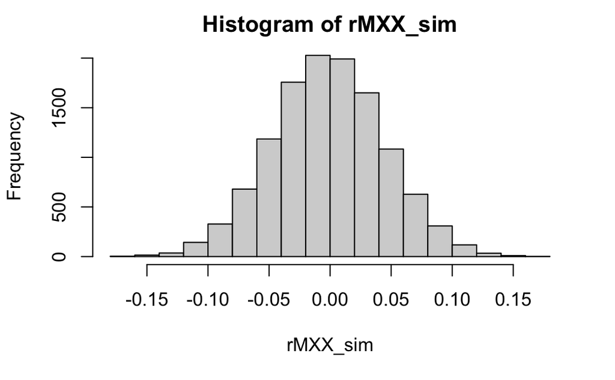

```r
hist(rMXX_sim)
```

# Pessimistic and optimistic scenarios

For the pessimistic scenario the mean will be 0.1 standard deviations less and the standard deviation will be 10% higher.

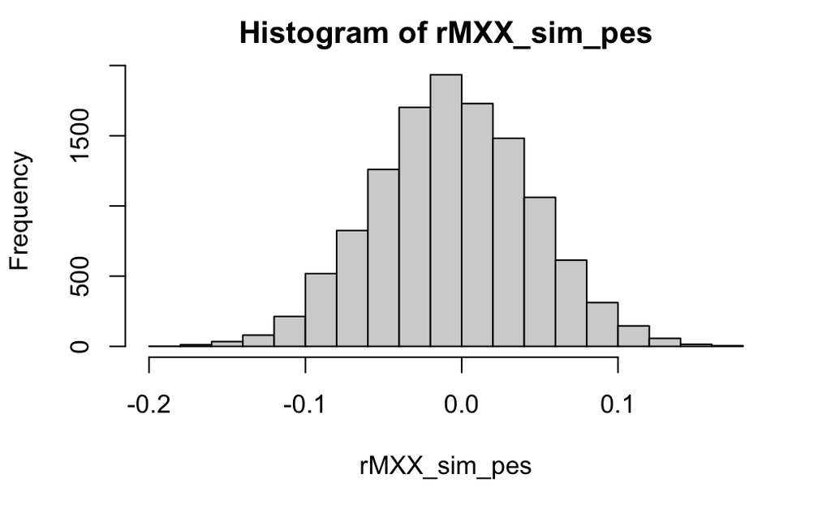

```r
mean_rMXX_pes <- mean_rMXX-0.1*sd_rMXX
sd_rMXX_pes <- sd_rMXX*1.1

rMXX_sim_pes <- rnorm(12*years, mean = mean_rMXX_pes, sd=sd_rMXX_pes)

hist(rMXX_sim_pes)
```

For the optimistic scenario the mean will be 0.1 standard deviations higher and the standard deviation will be 10% lower than the original.

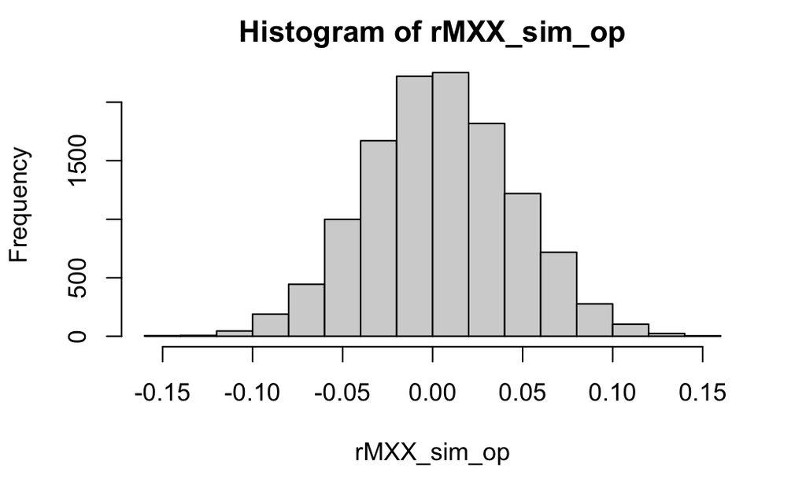

```r
mean_rMXX_op <- mean_rMXX+0.1*sd_rMXX
sd_rMXX_op <- sd_rMXX*.9

rMXX_sim_op <- rnorm(n=12*years, mean = mean_rMXX_op, sd=sd_rMXX_op)

hist(rMXX_sim_op)
```

Get the simulated annual returns for the 1000 years and then get the average

```r
simulated_data = data.frame(cbind(rMXX_sim,rMXX_sim_pes,rMXX_sim_op))

simulated_data$year <- rep(seq(1:1000),each=12)
```

Compute the annual return for every year using the functions groupby and summarize.

```r
library(dplyr)
annual_returns <- simulated_data %>%
   group_by(year) %>%
   summarise(a_rMXX_sim= sum(rMXX_sim),
             a_rMXX_sim_pes= sum(rMXX_sim_pes),
             a_rMXX_sim_op = sum(rMXX_sim_op))

head(annual_returns)
```

| year | a_rMXX_sim | a_rMXX_sim_pes | a_rMXX_sim_op |
| --- | --- | --- | --- |
| 1 | 0.090221674 | -0.21989564 | 0.326760661 |
| 2 | -0.127686030 | -0.05573476 | -0.283883488 |
| 3 | -0.088320763 | 0.27509420 | 0.379786530 |
| 4 | -0.209148783 | -0.21053529 | 0.204820567 |
| 5 | -0.006762702 | -0.09996650 | 0.004481552 |
| 6 | 0.287502266 | -0.18620051 | -0.310932411 |

Calculate the average return of the 1000 years

```r
annual_forecast_returns <- apply(annual_returns[,2:4],2,mean)
annual_forecast_returns
```

```
    a_rMXX_sim a_rMXX_sim_pes  a_rMXX_sim_op
   -0.01824301    -0.06723220     0.04977003
```

Calculate the annual volatility or the standard deviation

```r
sd_annual_forecast_returns <- apply(annual_returns[,2:4],2,sd)
sd_annual_forecast_returns
```

```
    a_rMXX_sim a_rMXX_sim_pes  a_rMXX_sim_op
     0.1607553      0.1726961      0.1430504
```

# Estimate the prediction for the stock return

Estimation annual expected return

```r
base_ALFA <- sumreg$coefficients[1,1] + sumreg$coefficients[2,1]*annual_forecast_returns[1]
base_ALFA
```

```
 a_rMXX_sim
-0.05011566
```

Pessimistic Forecast

```r
pes_ALFA <- sumreg$coefficients[1,1] + sumreg$coefficients[2,1]*annual_forecast_returns[2]
pes_ALFA
```

```
a_rMXX_sim_pes
    -0.1433056
```

Optimistic forecast

```r
op_ALFA <- sumreg$coefficients[1,1] + sumreg$coefficients[2,1]*annual_forecast_returns[3]
op_ALFA
```

```
a_rMXX_sim_op
   0.07926247
```